# R You Ready? An I/O Psychologist’s Guide to R & Rstudio

My January 16, 2024 METRO workshop is now a blog post, covering the essential 20% of R syntax for 80% of data analysis tasks. This blog post is designed for both R beginners and those seeking a refresher.

R

Workshop

Author

Affiliation

[Md Allama Ikbal Sijan](https://sijan14.github.io/sijan_portfolio)

Doctorate of Industrial-Organizational Psychology (Data Science) @ Montclair State University

Published

January 15, 2024

## 🌟 Introduction

In recent years, the R programming language emerged as the industry standard in social science research, owing to its robust statistical analysis tools, powerful data visualization capabilities, and a rich ecosystem of packages. Its open-source nature and emphasis on reproducibility further propelled its widespread adoption. This workshop, titled “R You Ready? An I/O Psychologist’s Guide to R and RStudio,” was tailored for both R novices and those seeking a refresher, focusing on the essential 20% of R syntax that facilitated 80% of data analysis tasks. Participants were introduced to the RStudio environment and fundamental R syntax, followed by hands-on sessions covering data transformation (dplyr), data visualization (ggplot2), statistical analyses (lm, stats), APA-style reporting (markdown, apa, papaja), and text mining (stringr, tidytext). The workshop concluded with collaborative problem-solving sessions to reinforce the concepts learned. The aim was to introduce students and practitioners to the power of R to carry out basic and advanced analyses, along with the capability to visualize and report findings.

[interactive chart not shown]

## 🧹 Tutorial #1 (Cleaning)

### Getting Started

Before diving into the transformations, let’s load the necessary package and dataset. You can download the [dataset](https://drive.google.com/file/d/1zUQf6jiZq7vq1GzktL0lIo__uaVj7Vhr/view?usp=sharing) to follow along.

```r
# Uncomment the next four lines if you haven't installed the package
# install.packages("tidyverse")
# install.packages("psych")
# install.packages("lsr")
# install.packages("apaTables")
library(tidyverse)
library(psych)
library(lsr)
library(apaTables)

# Loading the dataset
df <- read_csv("IBM HR Data.csv")

# Checking all the column names
names(df)
```

```
 [1] "Age"                      "Attrition"
 [3] "BusinessTravel"           "DailyRate"
 [5] "Department"               "DistanceFromHome"
 [7] "Education"                "EducationField"
 [9] "EmployeeCount"            "EmployeeNumber"
[11] "Application ID"           "EnvironmentSatisfaction"
[13] "Gender"                   "HourlyRate"
[15] "JobInvolvement"           "JobLevel"
[17] "JobRole"                  "JobSatisfaction"
[19] "MaritalStatus"            "MonthlyIncome"
[21] "MonthlyRate"              "NumCompaniesWorked"
[23] "Over18"                   "OverTime"
[25] "PercentSalaryHike"        "PerformanceRating"
[27] "RelationshipSatisfaction" "StandardHours"
[29] "StockOptionLevel"         "TotalWorkingYears"
[31] "TrainingTimesLastYear"    "WorkLifeBalance"
[33] "YearsAtCompany"           "YearsInCurrentRole"
[35] "YearsSinceLastPromotion"  "YearsWithCurrManager"
[37] "Employee Source"
```

### Sorting Data

Sorting is often one of the first transformations you’ll perform. Here’s how to do it in base R and tidyverse.

##### Option 1: Base R

In base R, you can use the `order()` function to sort by one or more columns:

```r
# Sort by age in ascending order
index <- order(df$Age)
df <- df[index, ]
```

##### Option 2: Tidyverse

The `arrange()` function from dplyr is a more concise and readable option:

```r
# Sort by multiple columns: Age (descending) and DailyRate (ascending)
df <- arrange(df, desc(Age), DailyRate)
```

### Renaming Columns

Renaming columns is another frequent task, especially when preparing data for analysis or visualization.

##### Option 1: Base R

Use the `colnames()` function to rename specific columns:

```r
# Rename the first column (age)
colnames(df)[1] <- "how_old"
```

##### Option 2: Tidyverse

The `rename()` function provides an intuitive way to rename columns:

```r
# Rename "how_old" back to "age"
df <- rename(df, "age" = "how_old")
```

### Filtering Data

Filtering rows based on specific conditions is crucial for focusing your analysis. Let’s filter for single employees earning over $10,000 per month:

```r
# Filter rows where MaritalStatus is "Single" and MonthlyIncome > 10000
single_rich <- df %>%
  filter(MaritalStatus == "Single", MonthlyIncome > 10000)
```

The pipe operator (`%>%`) from the tidyverse makes it easy to chain multiple operations.

### Summarizing Data

Summarization provides insights into key metrics like mean and standard deviation. Here’s how to summarize the filtered data:

```r
# summarizing the subset data
single_rich %>%
  summarise(Mean = mean(MonthlyIncome), SD = sd(MonthlyIncome))
```

```
# A tibble: 1 × 2
    Mean    SD
   <dbl> <dbl>
1 15043. 3200.
```

This calculates the average (Mean) and standard deviation (SD) of the MonthlyIncome column for the filtered subset.

### Subsetting Columns

Selecting specific columns is often necessary to focus on relevant data or remove unnecessary variables. You can use the `select()` function from the **tidyverse** to keep only the desired columns:

```r
# Keep specific columns
df %>%
  select(Attrition, DailyRate, Department, Education)
```

```
# A tibble: 23,532 × 4
   Attrition        DailyRate Department             Education
   <chr>                <dbl> <chr>                      <dbl>
 1 Current employee       370 Research & Development         4
 2 Current employee       370 Research & Development         4
 3 Current employee       370 Research & Development         4
 4 Current employee       370 Research & Development         4
 5 Current employee       370 Research & Development         4
 6 Current employee       370 Research & Development         4
 7 Current employee       370 Research & Development         4
 8 Current employee       370 Research & Development         4
 9 Current employee       370 Research & Development         4
10 Current employee       370 Research & Development         4
# ℹ 23,522 more rows
```

This selects only the *Attrition*, *DailyRate*, *Department*, and *Education* columns.

To drop specific columns, use the `select()` function with the negation operator `!`:

```r
# Drop unnecessary columns
df <- df %>%
  select(!c(EmployeeCount, StandardHours, Over18))
```

This removes the *EmployeeCount*, *StandardHours*, and *Over18* columns.

### Grouping Data by Variable

Grouping rows is helpful for summarizing data by categories. Here, we’ll group the data by EducationField and count the number of occurrences in each category.

```r
# Group by EducationField and count rows
df %>%
  group_by(EducationField) %>%
  count() %>%
  arrange(desc(n))
```

```
# A tibble: 9 × 2
# Groups:   EducationField [9]
  EducationField       n
  <chr>            <int>
1 Life Sciences     9725
2 Medical           7393
3 Marketing         2541
4 Technical Degree  2105
5 Other             1311
6 Human Resources    446
7 <NA>                 9
8 3                    1
9 Test                 1
```

This code:

1. Groups the data by *EducationField*.
2. Counts the rows in each group.
3. Arranges the groups in descending order by count (n).

### Recoding Variables

Recoding variables is a common task when transforming categorical data into numerical or more meaningful labels. First, let’s check the frequency of each category in the *Attrition* column:

```r
# View the distribution of Attrition
table(df$Attrition)
```

```
     Current employee           Termination Voluntary Resignation
                19714                    96                  3709
```

You can use the `recode()` function from the tidyverse to assign new values to the categories:

```r
# Recode Attrition variable
df$Attrition <- recode(df$Attrition,
                       "Current employee" = 0,
                       "Termination" = 1,
                       "Voluntary Resignation" = 2)
```

This transforms Attrition into a numerical variable with the following mapping:

- 0: Current employee
- 1: Termination
- 2: Voluntary Resignation

[interactive chart not shown]

## 🎨 Tutorial #2 (Visuals)

We will use **ggplot2** to create visually appealing scatterplots, apply faceting for multi-panel plots, and customize plots for better presentation. These techniques are essential for exploratory data analysis and communicating insights effectively.

### Scatterplots in ggplot2

Scatterplots are a powerful way to visualize relationships between two continuous variables.

Here’s how to create a simple scatterplot of *YearsAtCompany* vs. *TotalWorkingYears* with points colored red:

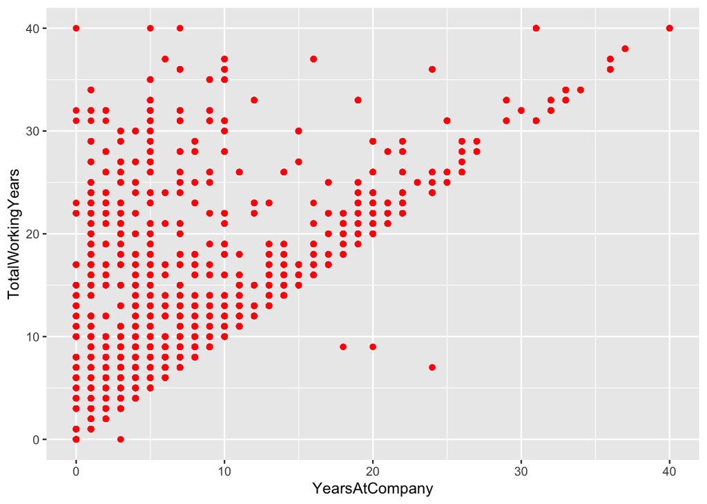

```r
# Basic scatterplot
ggplot(data = df) +
  geom_point(aes(x = YearsAtCompany, y = TotalWorkingYears), color = "Red")
```

This code plots *YearsAtCompany* on the x-axis and *TotalWorkingYears* on the y-axis with red points.

##### Adding Aesthetic Mappings

To add another dimension, such as coloring points by *MaritalStatus*, use the `aes()` function:

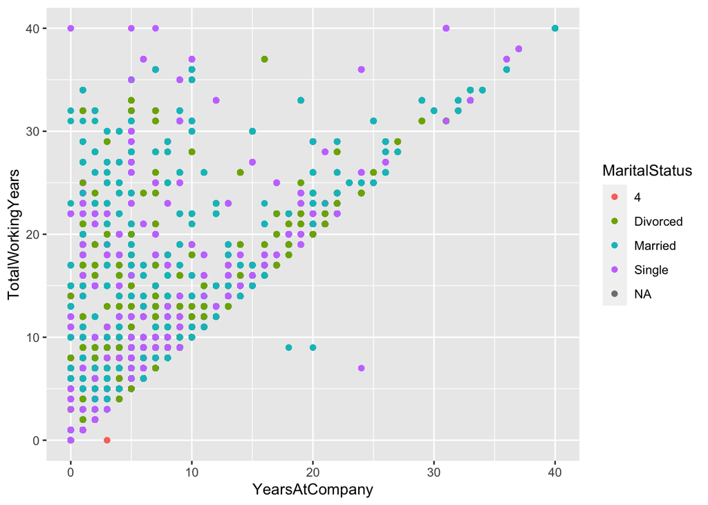

```r
# Scatterplot with points colored by MaritalStatus
ggplot(data = df) +
  geom_point(aes(x = YearsAtCompany, y = TotalWorkingYears, color = MaritalStatus))
```

### Faceting for Multi-Panel Plots

Faceting allows you to split the data into panels based on a categorical variable.

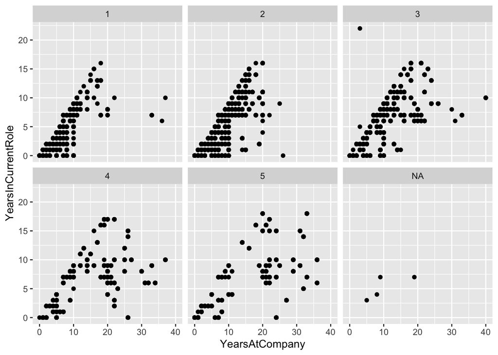

```r
# Faceted scatterplot by JobLevel
ggplot(data = df) +
  geom_point(aes(x = YearsAtCompany, y = YearsInCurrentRole)) +
  facet_wrap(~JobLevel, nrow = 2)
```

This creates separate scatterplots for each level of JobLevel, arranged in two rows.

### More Cusomization

For this section, we’ll use the built-in mpg dataset. To enhance a scatterplot, you can map multiple aesthetics (e.g., color and size), customize axis labels, and add a title:

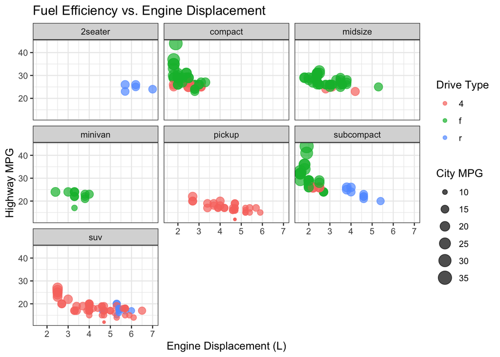

```r
# Load the dataset
data(mpg)

# Scatterplot with multiple aesthetics and customizations
ggplot(mpg, aes(x = displ, y = hwy, color = drv, size = cty)) +
  geom_point(alpha = 0.7) + # Add points with transparency
  # Customize axis labels and plot titles
  labs(title = "Fuel Efficiency vs. Engine Displacement",
       x = "Engine Displacement (L)",
       y = "Highway MPG",
       color = "Drive Type",
       size = "City MPG") +
  # Apply a theme
  theme_bw() +
  facet_wrap(~class)
```

Here’s what this code does:

- Aesthetics: Maps drv (drive type) to color and cty (city MPG) to point size.
- Labels: Adds a title, and custom axis labels, and modifies the legend titles.
- Theme: Applies a clean, white background theme (theme_bw()).
- Faceting: Creates facets for each vehicle class.

[interactive chart not shown]

## 📈 Tutorial #3 (Analysis)

### Summary and Frequency Tables

Use `summary()` and `table()` to calculate basic descriptive statistics and frequency counts.

```r
# Descriptive statistics for numeric variables
summary(df$WorkLifeBalance)
```

```
   Min. 1st Qu.  Median    Mean 3rd Qu.    Max.    NA's
  1.000   2.000   3.000   2.761   3.000   4.000      10
```

```r
# Frequency table for categorical variables
table(df$Gender)
```

```
     1      2 Female   Male
     1      1   9400  14120
```

Using the `describe` function from the **psych** Package for Detailed Summaries of numeric variables

```r
# Descriptive statistics for MonthlyIncome
describe(df$MonthlyIncome)
```

```
   vars     n    mean      sd median trimmed     mad  min   max range skew
X1    1 23516 6502.76 4705.99   4936 5666.19 3278.03 1009 19999 18990 1.37
   kurtosis    se
X1        1 30.69
```

### t-tests

A t-test is used to compare the means of two groups. Here, we examine differences in *JobSatisfaction* between genders.

```r
# Filtering Gender
df <- df %>%
  filter(Gender %in% c("Female", "Male"))

# Perform t-test
t.test(df$JobSatisfaction ~ df$Gender, var.equal = TRUE)
```

```
    Two Sample t-test

data:  df$JobSatisfaction by df$Gender
t = -5.0624, df = 23511, p-value = 4.171e-07
alternative hypothesis: true difference in means between group Female and group Male is not equal to 0
95 percent confidence interval:
 -0.10296313 -0.04548644
sample estimates:
mean in group Female   mean in group Male
            2.681247             2.755472
```

##### Effect Size

Effect size provides a measure of the magnitude of differences. We calculate Cohen’s D using the **lsr** package.

```r
# Cohen's D for JobSatisfaction by Gender
cohensD(df$JobSatisfaction ~ df$Gender)
```

```
[1] 0.0674014
```

### One-Way ANOVA

ANOVA (Analysis of Variance) is used to compare the means of more than two groups. We analyze *JobSatisfaction* across *Department*.

```r
# Convert Department to factor
class(df$Department) # Check class
```

```
[1] "character"
```

```r
df$Department <- as.factor(df$Department) # Convert to factor

# Conduct ANOVA
anovaTest <- aov(df$JobSatisfaction ~ df$Department)
summary(anovaTest)
```

```
                 Df Sum Sq Mean Sq F value Pr(>F)
df$Department     2      1   0.363   0.299  0.742
Residuals     23499  28524   1.214
18 observations deleted due to missingness
```

##### Effect Size

after conducting the ANOVA, we apply Tukey’s HSD to compare the *JobSatisfaction* between different levels of *Department*.

```r
# Post-hoc Tukey's HSD test
TukeyHSD(anovaTest)
```

```
  Tukey multiple comparisons of means
    95% family-wise confidence level

Fit: aov(formula = df$JobSatisfaction ~ df$Department)

$`df$Department`
                                              diff         lwr        upr
Research & Development-Human Resources 0.021787253 -0.06179058 0.10536508
Sales-Human Resources                  0.027838399 -0.05866972 0.11434652
Sales-Research & Development           0.006051146 -0.03093437 0.04303666
                                           p adj
Research & Development-Human Resources 0.8141109
Sales-Human Resources                  0.7310521
Sales-Research & Development           0.9221490
```

### Correlation Analysis

The correlation between two continuous variables can be calculated using the `cor()` or `cor.test` function. Here, we calculate the correlation between *JobInvolvement* and *RelationshipSatisfaction.*

```r
# Calculate correlation, using complete observations only
cor.test(df$JobInvolvement, df$RelationshipSatisfaction, use = "complete.obs")
```

```
    Pearson's product-moment correlation

data:  df$JobInvolvement and df$RelationshipSatisfaction
t = 5.1325, df = 23506, p-value = 2.882e-07
alternative hypothesis: true correlation is not equal to 0
95 percent confidence interval:
 0.02068330 0.04622137
sample estimates:
      cor
0.0334578
```

### Multiple Linear Regression

A multiple linear regression model can be used to predict the value of a continuous dependent variable based on multiple independent variables. Here, we build a model predicting *JobSatisfaction*.

```r
# Multiple linear regression model
model1 <- lm(JobSatisfaction ~
              age + Gender + JobLevel + MonthlyIncome,
            data = df)

# Display the summary of the model
summary(model1)
```

```
Call:
lm(formula = JobSatisfaction ~ age + Gender + JobLevel + MonthlyIncome,
    data = df)

Residuals:
    Min      1Q  Median      3Q     Max
-2.0440 -0.7585  0.2526  1.2248  1.4585

Coefficients:
                Estimate Std. Error t value Pr(>|t|)
(Intercept)    2.777e+00  3.336e-02  83.237  < 2e-16 ***
age           -3.597e-03  8.127e-04  -4.426 9.63e-06 ***
GenderMale     7.321e-02  1.468e-02   4.989 6.13e-07 ***
JobLevel       6.273e-02  1.948e-02   3.220  0.00128 **
MonthlyIncome -1.412e-05  4.568e-06  -3.090  0.00200 **
---
Signif. codes:  0 '***' 0.001 '**' 0.01 '*' 0.05 '.' 0.1 ' ' 1

Residual standard error: 1.101 on 23490 degrees of freedom
  (25 observations deleted due to missingness)
Multiple R-squared:  0.002353,  Adjusted R-squared:  0.002183
F-statistic: 13.85 on 4 and 23490 DF,  p-value: 2.77e-11
```

```r
# Second model including EducationField as a factor variable
model2 <- lm(JobSatisfaction ~
               as.factor(EducationField) +
               age + Gender + JobLevel +
               MonthlyIncome,
             data = df)

# Display the summary of the model
summary(model2)
```

```
Call:
lm(formula = JobSatisfaction ~ as.factor(EducationField) + age +
    Gender + JobLevel + MonthlyIncome, data = df)

Residuals:
    Min      1Q  Median      3Q     Max
-2.0400 -0.7611  0.2494  1.2052  1.5089

Coefficients:
                                            Estimate Std. Error t value
(Intercept)                                2.683e+00  6.190e-02  43.347
as.factor(EducationField)Life Sciences     1.459e-01  5.333e-02   2.735
as.factor(EducationField)Marketing         8.328e-02  5.653e-02   1.473
as.factor(EducationField)Medical           5.383e-02  5.370e-02   1.002
as.factor(EducationField)Other             8.145e-02  6.036e-02   1.350
as.factor(EducationField)Technical Degree  5.170e-02  5.740e-02   0.901
as.factor(EducationField)Test              3.908e-01  1.101e+00   0.355
age                                       -3.670e-03  8.132e-04  -4.513
GenderMale                                 7.362e-02  1.467e-02   5.018
JobLevel                                   6.450e-02  1.948e-02   3.311
MonthlyIncome                             -1.453e-05  4.568e-06  -3.180
                                          Pr(>|t|)
(Intercept)                                < 2e-16 ***
as.factor(EducationField)Life Sciences    0.006240 **
as.factor(EducationField)Marketing        0.140708
as.factor(EducationField)Medical          0.316139
as.factor(EducationField)Other            0.177169
as.factor(EducationField)Technical Degree 0.367754
as.factor(EducationField)Test             0.722669
age                                       6.42e-06 ***
GenderMale                                5.27e-07 ***
JobLevel                                  0.000933 ***
MonthlyIncome                             0.001472 **
---
Signif. codes:  0 '***' 0.001 '**' 0.01 '*' 0.05 '.' 0.1 ' ' 1

Residual standard error: 1.1 on 23477 degrees of freedom
  (32 observations deleted due to missingness)
Multiple R-squared:  0.00395,   Adjusted R-squared:  0.003526
F-statistic:  9.31 on 10 and 23477 DF,  p-value: 1.403e-15
```

### Logistic Regression

Logistic regression is used when the dependent variable is binary. We transform Gender into a binary variable and predict it based on *MonthlyIncome* and *JobLevel*.

```r
# Convert Gender to binary variable (Male = 1, Female = 0)
df <- df %>%
  mutate(Gender = ifelse(Gender == "Male", 1, 0))

# Logistic regression model
logit <- glm(Gender ~ MonthlyIncome + JobLevel, data = df, family = "binomial")

# Display the summary of the logistic regression model
summary(logit)
```

```
Call:
glm(formula = Gender ~ MonthlyIncome + JobLevel, family = "binomial",
    data = df)

Coefficients:
                Estimate Std. Error z value Pr(>|z|)
(Intercept)    5.965e-01  3.214e-02  18.558  < 2e-16 ***
MonthlyIncome  2.086e-05  8.476e-06   2.461   0.0138 *
JobLevel      -1.575e-01  3.611e-02  -4.363 1.28e-05 ***
---
Signif. codes:  0 '***' 0.001 '**' 0.01 '*' 0.05 '.' 0.1 ' ' 1

(Dispersion parameter for binomial family taken to be 1)

    Null deviance: 31633  on 23503  degrees of freedom
Residual deviance: 31589  on 23501  degrees of freedom
  (16 observations deleted due to missingness)
AIC: 31595

Number of Fisher Scoring iterations: 4
```

```r
# Exponentiate the coefficients to get odds ratios
exp(coef(logit))
```

```
  (Intercept) MonthlyIncome      JobLevel
    1.8157319     1.0000209     0.8542492
```

[interactive chart not shown]

## 📝 Tutorial #4 (Reports)

We will use the `apaTables` package to format analysis outputs according to APA guidelines and export them to Word documents.

### APA Style Correlation Table

First, we create a correlation matrix using the `cor()` function for a subset of numeric columns from the dataset.

```r
# Subset of numeric columns for correlation analysis
num <- df[, c("age", "DailyRate", "DistanceFromHome",
              "HourlyRate", "MonthlyIncome")]

# Calculate the Pearson correlation matrix
corr_matrix <- cor(num, method = "pearson", use = "complete.obs")
```

Next, we use the `apa.cor.table()` function from the apaTables package to create a formatted APA-style table.

```r
# Create and save the APA correlation table
apa.cor.table(corr_matrix, table.number = 1, filename = "Correlation_table.doc")
```

```
Table 1

Means, standard deviations, and correlations with confidence intervals


  Variable            M    SD   1           2           3           4
  1. age              0.25 0.43

  2. DailyRate        0.20 0.45 -.30
                                [-.94, .79]

  3. DistanceFromHome 0.20 0.45 -.33        -.27
                                [-.94, .78] [-.93, .80]

  4. HourlyRate       0.20 0.44 -.35        -.20        -.21
                                [-.94, .77] [-.92, .83] [-.92, .83]

  5. MonthlyIncome    0.24 0.44 .24         -.35        -.32        -.35
                                [-.81, .93] [-.94, .77] [-.94, .78] [-.94, .77]


Note. M and SD are used to represent mean and standard deviation, respectively.
Values in square brackets indicate the 95% confidence interval.
The confidence interval is a plausible range of population correlations
that could have caused the sample correlation (Cumming, 2014).
 * indicates p < .05. ** indicates p < .01.
```

The above code will generate a Word document with the correlation table in APA format, and the file will be saved as “Correlation_table.doc”.

### APA Style ANOVA Table

We will use the `apa.aov.table()` function to format the ANOVA results into an APA-style table and save it to a Word document.

```r
# Create and save the APA ANOVA table
apa.aov.table(anovaTest, table.number = 2, filename = "Anova_table.doc")
```

```
Table 2

ANOVA results using df$JobSatisfaction as the dependent variable


     Predictor       SS    df      MS       F    p partial_eta2
   (Intercept)  7439.59     1 7439.59 6128.95 .000
 df$Department     0.73     2    0.36    0.30 .742          .00
         Error 28524.14 23499    1.21
 CI_90_partial_eta2

         [.00, .00]


Note: Values in square brackets indicate the bounds of the 90% confidence interval for partial eta-squared
```

This will generate a Word document containing the APA-formatted ANOVA table, saved as “Anova_table.doc”.

[interactive chart not shown]

## 💭 Conclusion

In this blog post, we covered key techniques for data manipulation, analysis, and reporting in R. We started with basic operations such as sorting, filtering, and renaming columns using both base R and the dplyr package. We then explored advanced visualization with ggplot2, creating customized scatterplots and faceted plots. The analysis section demonstrated t-tests, ANOVA, regression models, and post-hoc tests to analyze relationships in the data.

We also learned how to create APA-style tables for correlation matrices and ANOVA results using the apaTables package. While we’ve only scratched the surface of what we can do with R, these tutorials should provide a robust foundation for conducting data analysis in research, business, and academic contexts, while hopefully mitigating initial anxieties associated with learning to code. Happy coding!

## 🔗 Reference

Wickham, H., & Grolemund, G. (2017). *R for data science: Import, tidy, transform, visualize, and model data* (1st ed.). O’Reilly Media.

## Citation

BibTeX citation:

```
@online{allama ikbal sijan2024,
  author = {Allama Ikbal Sijan, Md},
  title = {R {You} {Ready?} {An} {I/O} {Psychologist’s} {Guide} to {R}
    \& {Rstudio}},
  date = {2024-01-15},
  url = {https://sijan14.github.io/sijan_portfolio/posts/2024-12-31-R-Workshop/},
  langid = {en}
}
```

For attribution, please cite this work as:

Allama Ikbal Sijan, Md. 2024. “R You Ready? An I/O Psychologist’s Guide to R & Rstudio.” January 15, 2024. https://sijan14.github.io/sijan_portfolio/posts/2024-12-31-R-Workshop/.